# Programa de retenção de clientes de telecomunicações

R Notebook

Ewerson C. Pimenta e Marcos Antônio E. de Oliveira

Rio de Janeiro, 21 de agosto de 2018

## Introdução

Essa análise tem como principal foco verificar padrões e coomportamentos em clientes de telecomunicações que possuem maior propenção a deixar de ser cliente da empresa (sair da base / migração de clientes). Através de análise exploratória de dados incia-se um processo de descoberta dos dados e possíveis variáveis que viabilizam o reconhecimento de padrões de clientes de telco e, posteriormente, o uso de técnicas de análise preditiva para determinar os clientes que com maior probabilidade irão migrar.

[figure not shown]

## Banco de Dados

### Descrição

- Se deixou de ser cliente
- Serviços aderidos por cada cada cliente mobile
  - qtd. de linhas
  - internet
  - segurança online
  - backup online
  - seguro
  - suporte técnico
  - TV a cabo
- Informações da conta do cliente
  - Tempo da conta
  - Contrato
  - Método de pagamento
  - Conta online (sem impressão)
  - Encargos mensais
  - Total da conta
- Informações Demográficas do cliente
  - Gênero
  - Faixa etária
  - Possui parceiros ou dependentes

*Os dados em questão são públicos e disponíveis para download clicando [AQUI](https://www.kaggle.com/blastchar/telco-customer-churn/home).*

### Pacotes

```r
library(tidyverse)
library(highcharter)
library(cowplot)
```

### Leitura

```r
telco = read.csv2("WA_Fn-UseC_-Telco-Customer-Churn.csv", sep = ";", header = TRUE, na.strings = "")
#class(db)
```

### Estrutura

7.043 observações e 21 variáveis.

```r
glimpse(telco) #str(db)
```

```
## Observations: 7,043
## Variables: 21
## $ customerID       <fct> 7590-VHVEG, 5575-GNVDE, 3668-QPYBK, 7795-CFOC...
## $ gender           <fct> Female, Male, Male, Male, Female, Female, Mal...
## $ SeniorCitizen    <int> 0, 0, 0, 0, 0, 0, 0, 0, 0, 0, 0, 0, 0, 0, 0, ...
## $ Partner          <fct> Yes, No, No, No, No, No, No, No, Yes, No, Yes...
## $ Dependents       <fct> No, No, No, No, No, No, Yes, No, No, Yes, Yes...
## $ tenure           <dbl> 1, 34, 2, 45, 2, 8, 22, 10, 28, 62, 13, 16, 5...
## $ PhoneService     <fct> No, Yes, Yes, No, Yes, Yes, Yes, No, Yes, Yes...
## $ MultipleLines    <fct> No phone service, No, No, No phone service, N...
## $ InternetService  <fct> DSL, DSL, DSL, DSL, Fiber optic, Fiber optic,...
## $ OnlineSecurity   <fct> No, Yes, Yes, Yes, No, No, No, Yes, No, Yes, ...
## $ OnlineBackup     <fct> Yes, No, Yes, No, No, No, Yes, No, No, Yes, N...
## $ DeviceProtection <fct> No, Yes, No, Yes, No, Yes, No, No, Yes, No, N...
## $ TechSupport      <fct> No, No, No, Yes, No, No, No, No, Yes, No, No,...
## $ StreamingTV      <fct> No, No, No, No, No, Yes, Yes, No, Yes, No, No...
## $ StreamingMovies  <fct> No, No, No, No, No, Yes, No, No, Yes, No, No,...
## $ Contract         <fct> Month-to-month, One year, Month-to-month, One...
## $ PaperlessBilling <fct> Yes, No, Yes, No, Yes, Yes, Yes, No, Yes, No,...
## $ PaymentMethod    <fct> Electronic check, Mailed check, Mailed check,...
## $ MonthlyCharges   <dbl> 29.85, 56.95, 53.85, 42.30, 70.70, 99.65, 89....
## $ TotalCharges     <dbl> 29.85, 1889.50, 108.15, 1840.75, 151.65, 820....
## $ Churn            <fct> No, No, Yes, No, Yes, Yes, No, No, Yes, No, N...
```

Porcentagem de NA por variável

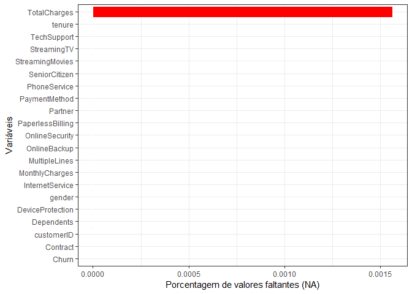

```r
options(repr.plot.width = 6, repr.plot.height = 4)
missing_data <- telco %>% summarise_all(funs(sum(is.na(.))/n()))
missing_data <- gather(missing_data, key = "variables", value = "percent_missing")
ggplot(missing_data, aes(x = reorder(variables, percent_missing), y = percent_missing)) +
geom_bar(stat = "identity", fill = "red", aes(color = I('white')), size = 0.3)+
xlab('Variáveis')+
ylab('Porcentagem de valores faltantes (NA)') +
coord_flip()+
theme_bw()
```

```r
cat("Existem", sum(is.na(telco$TotalCharges)), "observações faltantes na variável 'TotalCharges'")
```

```
## Existem 11 observações faltantes na variável 'TotalCharges'
```

Entretanto, esses valores faltantes apenas ocorrem quando a variável ‘tenure’ assume valor zero e consequentemente na variável ‘MonthlyCharges’ existem valores (diferente de zero). Ou seja, ‘TotalCharges’ apenas possui valores para meses (tenure) maiores ou iguais a um de permanência do cliente.

```r
telco[is.na(telco$TotalCharges), c(1, 6, 19, 20)]
```

|  | customerID | tenure | MonthlyCharges | TotalCharges |
| --- | --- | --- | --- | --- |
| 489 | 4472-LVYGI | 0 | 52.55 | NA |
| 754 | 3115-CZMZD | 0 | 20.25 | NA |
| 937 | 5709-LVOEQ | 0 | 80.85 | NA |
| 1083 | 4367-NUYAO | 0 | 25.75 | NA |
| 1341 | 1371-DWPAZ | 0 | 56.05 | NA |
| 3332 | 7644-OMVMY | 0 | 19.85 | NA |
| 3827 | 3213-VVOLG | 0 | 25.35 | NA |
| 4381 | 2520-SGTTA | 0 | 20.00 | NA |
| 5219 | 2923-ARZLG | 0 | 19.70 | NA |
| 6671 | 4075-WKNIU | 0 | 73.35 | NA |

[output cut: 1 more lines]

Optamos por remover essas observações do banco de dados uma vez que esses clientes não ficaram tempo suficiente (menos de um Mês) para avaliações e análises preditivas posteriores.

```r
telco <- telco[!is.na(telco$TotalCharges),]
telco[is.na(telco$TotalCharges), c(1, 6, 19, 20)]
```

| customerID | tenure | MonthlyCharges | TotalCharges |
| --- | --- | --- | --- |

```r
cat("Portanto, o novo banco de dados possui", dim(telco)[1], "observações.")
```

```
## Portanto, o novo banco de dados possui 7032 observações.
```

### Preparação de dados

Existem apenas 3 variáveis contínuas no banco de dados (‘Tenure’, ‘MonthlyCharges’ e ‘TotalCharges’). ‘SeniorCitizen’ está em formato de variável inteira (0 ou 1) e este será modificado para categórica (factor).

```r
telco <- telco[complete.cases(telco),]
telco$SeniorCitizen <- ifelse(telco$SeniorCitizen==1, 'Yes', 'No')
```

## Análise Exploratória

```r
glimpse(telco)
```

```
## Observations: 7,032
## Variables: 21
## $ customerID       <fct> 7590-VHVEG, 5575-GNVDE, 3668-QPYBK, 7795-CFOC...
## $ gender           <fct> Female, Male, Male, Male, Female, Female, Mal...
## $ SeniorCitizen    <chr> "No", "No", "No", "No", "No", "No", "No", "No...
## $ Partner          <fct> Yes, No, No, No, No, No, No, No, Yes, No, Yes...
## $ Dependents       <fct> No, No, No, No, No, No, Yes, No, No, Yes, Yes...
## $ tenure           <dbl> 1, 34, 2, 45, 2, 8, 22, 10, 28, 62, 13, 16, 5...
## $ PhoneService     <fct> No, Yes, Yes, No, Yes, Yes, Yes, No, Yes, Yes...
## $ MultipleLines    <fct> No phone service, No, No, No phone service, N...
## $ InternetService  <fct> DSL, DSL, DSL, DSL, Fiber optic, Fiber optic,...
## $ OnlineSecurity   <fct> No, Yes, Yes, Yes, No, No, No, Yes, No, Yes, ...
## $ OnlineBackup     <fct> Yes, No, Yes, No, No, No, Yes, No, No, Yes, N...
## $ DeviceProtection <fct> No, Yes, No, Yes, No, Yes, No, No, Yes, No, N...
## $ TechSupport      <fct> No, No, No, Yes, No, No, No, No, Yes, No, No,...
## $ StreamingTV      <fct> No, No, No, No, No, Yes, Yes, No, Yes, No, No...
## $ StreamingMovies  <fct> No, No, No, No, No, Yes, No, No, Yes, No, No,...
## $ Contract         <fct> Month-to-month, One year, Month-to-month, One...
## $ PaperlessBilling <fct> Yes, No, Yes, No, Yes, Yes, Yes, No, Yes, No,...
## $ PaymentMethod    <fct> Electronic check, Mailed check, Mailed check,...
## $ MonthlyCharges   <dbl> 29.85, 56.95, 53.85, 42.30, 70.70, 99.65, 89....
## $ TotalCharges     <dbl> 29.85, 1889.50, 108.15, 1840.75, 151.65, 820....
## $ Churn            <fct> No, No, Yes, No, Yes, Yes, No, No, Yes, No, N...
```

Visualizando, primeiramente, a variável categórica resposta de interesse ‘Churn’. Onde `Yes` significa que o cliente migrou (deixou de ser cliente) e `No` que ele permanece como cliente.

Mais especificamente, pelo ‘Churn’ fica claro o quantitativo de clientes que migraram no último mes. Cerca de 26% dos clientes deixaram de ser atendido pelos serviços da empresa no último mes.

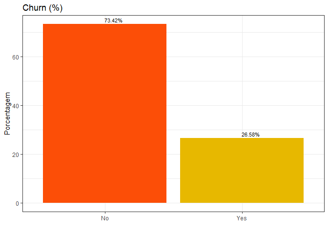

```r
options(repr.plot.width = 6, repr.plot.height = 4)
telco %>%
group_by(Churn) %>%
summarise(Count = n())%>%
mutate(percent = prop.table(Count)*100)%>%
ggplot(aes(reorder(Churn, -percent), percent), fill = Churn)+
geom_col(fill = c("#FC4E07", "#E7B800"))+
geom_text(aes(label = sprintf("%.2f%%", percent)), hjust = 0.01,vjust = -0.5, size =3)+
theme_bw()+
xlab("") +
ylab("Porcentagem")+
ggtitle("Churn (%)")
```

- Gênero - A porcentagem de churn é praticamente a mesma entre gêneros masculino e feminino.
- A porcentagem de churn é maior entre os cidadãos de terceira idade (senior citizens)
- Clientes com parceiros e dependentes têm menores taxas de Churn comparadas àquele que não tem parceiros e dependentes.

```r
library(ggpubr)
```

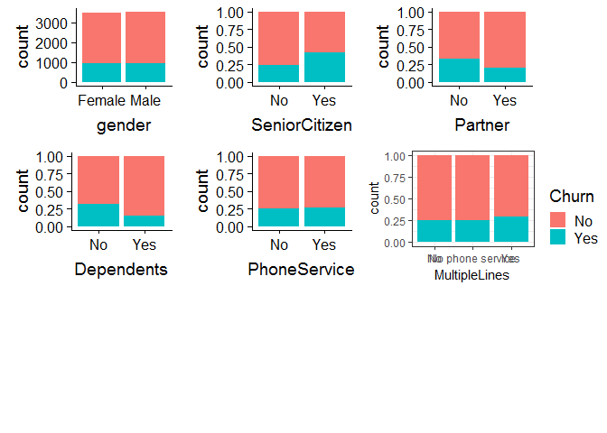

```r
p1 = ggplot(telco, aes(x=gender,fill=Churn))+ geom_bar()
p2 = ggplot(telco, aes(x=SeniorCitizen,fill=Churn))+ geom_bar(position = 'fill')
p3 = ggplot(telco, aes(x=Partner,fill=Churn))+ geom_bar(position = 'fill')
p4 = ggplot(telco, aes(x=Dependents,fill=Churn))+ geom_bar(position = 'fill')
p5 = ggplot(telco, aes(x=PhoneService,fill=Churn))+ geom_bar(position = 'fill')
p6 = ggplot(telco, aes(x=MultipleLines,fill=Churn))+ geom_bar(position = 'fill')+theme_bw()
ggarrange(p1, p2, p3, p4, p5,p6, ncol=3, nrow=3, common.legend = TRUE, legend="right")
```

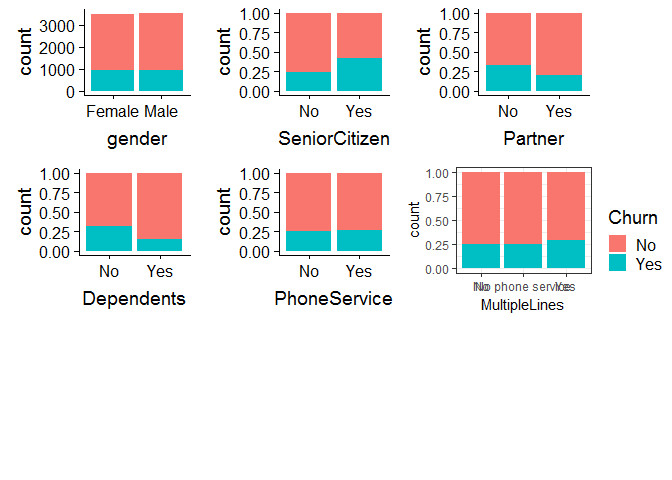

```r
p2.1 = ggplot(telco, aes(x=InternetService,fill=Churn))+ geom_bar(position = 'fill') + scale_x_discrete(labels = function(x) str_wrap(x, width = 10))
p2.2 = ggplot(telco, aes(x=OnlineSecurity,fill=Churn))+ geom_bar(position = 'fill') + scale_x_discrete(labels = function(x) str_wrap(x, width = 10))
p2.3 = ggplot(telco, aes(x=OnlineBackup,fill=Churn))+ geom_bar(position = 'fill') + scale_x_discrete(labels = function(x) str_wrap(x, width = 10))
p2.4 = ggplot(telco, aes(x=DeviceProtection,fill=Churn))+ geom_bar(position = 'fill') + scale_x_discrete(labels = function(x) str_wrap(x, width = 10))
p2.5 = ggplot(telco, aes(x=TechSupport,fill=Churn))+ geom_bar(position = 'fill') + scale_x_discrete(labels = function(x) str_wrap(x, width = 10))
p2.6 = ggplot(telco, aes(x=StreamingTV,fill=Churn))+ geom_bar(position = 'fill')+theme_bw()+scale_x_discrete(labels = function(x) str_wrap(x, width = 10))
ggarrange(p1, p2, p3, p4, p5,p6, ncol=3, nrow=3, common.legend = TRUE, legend="right")
```

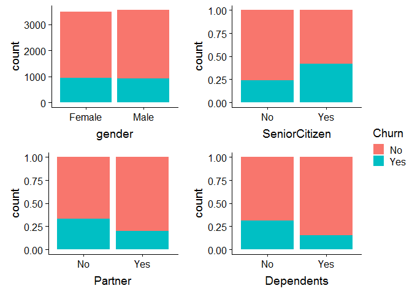

```r
p3.1 = ggplot(telco, aes(x=StreamingMovies,fill=Churn))+ geom_bar(position = 'fill')+ scale_x_discrete(labels = function(x) str_wrap(x, width = 10))
p3.2 = ggplot(telco, aes(x=Contract,fill=Churn))+ geom_bar(position = 'fill')+scale_x_discrete(labels = function(x) str_wrap(x, width = 10))
p3.3 = ggplot(telco, aes(x=PaperlessBilling,fill=Churn))+ geom_bar(position = 'fill')+scale_x_discrete(labels = function(x) str_wrap(x, width = 10))
p3.4 = ggplot(telco, aes(x=PaymentMethod,fill=Churn))+ geom_bar(position = 'fill')+theme_bw()+scale_x_discrete(labels = function(x) str_wrap(x, width = 10))
ggarrange(p1, p2, p3, p4, ncol=2, nrow=2, common.legend = TRUE, legend="right")
```

Analyzing the three continuous variables w.r.t CHURN:

Tenure: The median tenure for customers who have left is around 10 months, there are few outliers though.

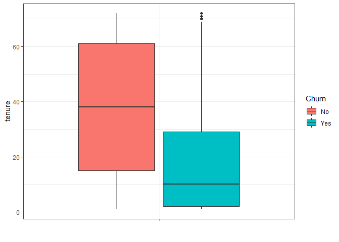

```r
options(repr.plot.width =6, repr.plot.height = 2)
ggplot(telco, aes(y= tenure, x = "", fill = Churn)) +
geom_boxplot()+
theme_bw()+
xlab(" ")
```

```r
hcboxplot(x = telco$tenure, var = telco$Churn,
          outliers = FALSE) %>%
  hc_title(text = "Boxplot do tempo de fidelização do cliente X Desistência") %>%
  hc_chart(type = "column") %>% # to put box vertical
  hc_exporting(enabled = TRUE)  # enable exporting option
```

[interactive chart not shown]

MonthlyCharges: Customers who have churned, have high monthly charges. The median is above 75.

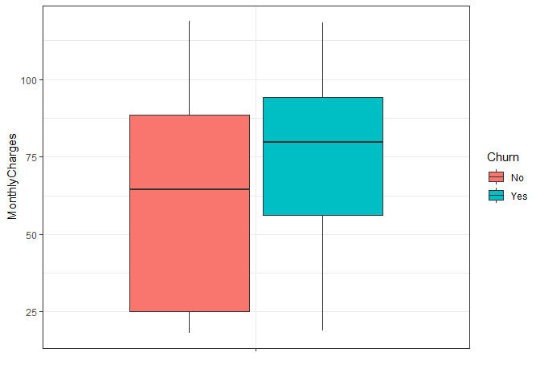

```r
ggplot(telco, aes(y= MonthlyCharges, x = "", fill = Churn)) +
geom_boxplot()+
theme_bw()+
xlab(" ")
```

```r
hcboxplot(x = telco$MonthlyCharges, var = telco$Churn,
          outliers = FALSE) %>%
  hc_title(text = "Boxplot dos encargos mensais X Desistência") %>%
  hc_chart(type = "column") %>% # to put box vertical
  hc_exporting(enabled = TRUE)  # enable exporting option
```

[interactive chart not shown]

TotalCharges:* The median Total charges of customers who have churned is low but again with few outliers.

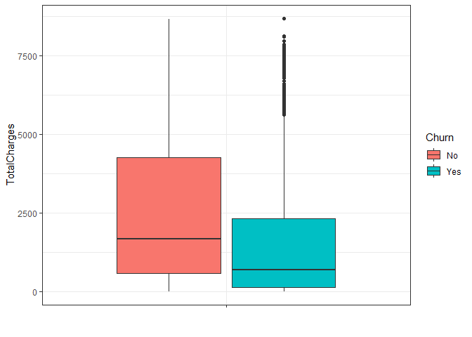

```r
ggplot(telco, aes(y= TotalCharges, x = "", fill = Churn)) +
geom_boxplot()+
theme_bw()+
xlab(" ")
```

```r
hcboxplot(x = telco$TotalCharges, var = telco$Churn,
          outliers = FALSE) %>%
  hc_title(text = "Boxplot dos encargos totais X Desistência") %>%
  hc_chart(type = "column") %>% # to put box vertical
  hc_exporting(enabled = TRUE)  # enable exporting option
```

[interactive chart not shown]